# Estimate parameters in a PBPK model

Metrum Research Group

# 1 Packages and setup

```r
library(tidyverse)
library(PKPDmisc)
library(mrgsolve)
source("script/functions.R")
source("script/global.R")
```

```r
set.seed(10101)
```

```r
theme_set(theme_bw() + theme(legend.position = "top"))
scale_colour_discrete <- function(...) scale_color_brewer(palette="Set2")
```

Models are located here:

```r
model_dir <- "model"
```

# 2 Reference

**Quantitative Analyses of Hepatic OATP-Mediated Interactions Between Statins and Inhibitors Using PBPK Modeling With a Parameter Optimization Method**

- T Yoshikado, K Yoshida, N Kotani, T Nakada, R Asaumi, K Toshimoto, K Maeda, H Kusuhara and Y Sugiyama
- CLINICAL PHARMACOLOGY & THERAPEUTICS | VOLUME 100 NUMBER 5 | NOVEMBER 2016
- https://www.ncbi.nlm.nih.gov/pubmed/27170342

# 3 Data

- Example taken from figure 4a from the publication
- Using this as example data to fit

```r
data.file <- "data/fig4a.csv"

data <-
  data.file %>%
  read_csv() %>%
  mutate(
    profile = NULL,
    type=ID,
    typef=factor(ID, labels = c("Statin", "Statin+CsA")),
    DV = ifelse(DV==-1, NA_real_, DV)
  )


data
```

```
. # A tibble: 23 x 8
.       ID  time     DV  evid   amt   cmt  type typef
.    <dbl> <dbl>  <dbl> <dbl> <dbl> <dbl> <dbl> <fct>
.  1     2  0     NA        1  2000     2     2 Statin+CsA
.  2     2  1     NA        1    30     1     2 Statin+CsA
.  3     2  1.49  73.7      0     0     0     2 Statin+CsA
.  4     2  1.99 102.       0     0     0     2 Statin+CsA
.  5     2  2.49  59.9      0     0     0     2 Statin+CsA
.  6     2  3.00  37.6      0     0     0     2 Statin+CsA
.  7     2  3.97  15.7      0     0     0     2 Statin+CsA
.  8     2  5.01   9.24     0     0     0     2 Statin+CsA
.  9     2  6.99   3.54     0     0     0     2 Statin+CsA
. 10     2  9.01   2.22     0     0     0     2 Statin+CsA
. # … with 13 more rows
```

```r
data %>% filter(evid==1)
```

```
. # A tibble: 3 x 8
.      ID  time    DV  evid   amt   cmt  type typef
.   <dbl> <dbl> <dbl> <dbl> <dbl> <dbl> <dbl> <fct>
. 1     2     0    NA     1  2000     2     2 Statin+CsA
. 2     2     1    NA     1    30     1     2 Statin+CsA
. 3     1     1    NA     1    30     1     1 Statin
```

- The goal is to fit the pitavastatin data either alone or in combination with cyclosporin administered 1 hour before the pitavastatin

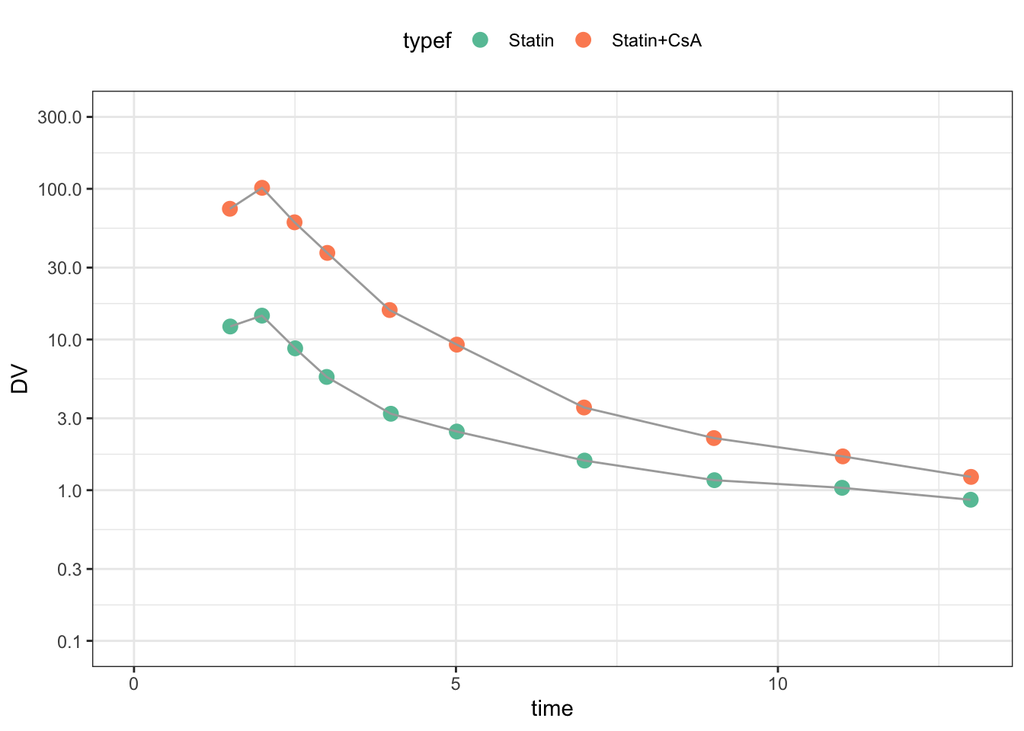

```r
ggplot(data=data,aes(time,DV)) +
  geom_point(aes(col = typef), size = 3) +
  geom_line(col = "darkgrey", aes(group = typef)) +
  scale_y_continuous(trans="log", limits=c(0.1,300), breaks=logbr())
```

# 4 PBPK model: pitavastatin / CsA DDI

- Check out the model / data with a quick simulation

```r
mod <- mread_cache("yoshikado", model_dir)
```

Make some persistent updates to the model

- Simulate out to 14 hours
- Only interested in `CP`, the pitavastatin concentration

```r
mod <- mod %>% update(end=14, delta=0.1) %>% Req(CP)
```

A practice simulation

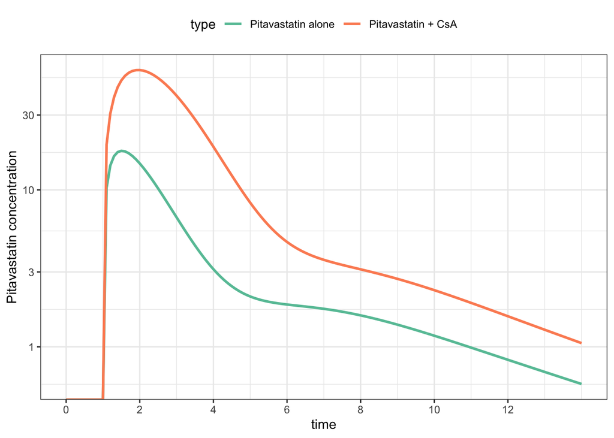

```r
dose <- filter(data, evid==1) %>% mutate(typef=NULL)

sims <-
  mod %>%
  mrgsim_d(dose, obsaug=TRUE) %>%
  mutate(type = typef(ID))

ggplot(sims, aes(time,CP,col=type)) +
  geom_line(lwd = 1) +
  scale_x_continuous(breaks = seq(0,12,2)) +
  scale_y_log10(name = "Pitavastatin concentration")
```

```r
sims %>%
  group_by(type) %>%
  summarise(auc = auc_partial(time,CP)) %>%
  mutate(fold_increase = auc /first(auc))
```

```
. # A tibble: 2 x 3
.   type                 auc fold_increase
.   <fct>              <dbl>         <dbl>
. 1 Pitavastatin alone  44.1          1
. 2 Pitavastatin + CsA 161.           3.65
```

# 5 Objective function

- Least squares objective function
- Weighted by the observations

Arguments:

- `dv` the observed data
- `pred` the predicted data

```r
wss <- function(dv, pred, weight = 1/dv) {
  sum(((dv-pred)*weight)^2,na.rm=TRUE)
}
```

### 5.0.1 Prediction function

- Let’s go through step by step what each line is doing for us

Arguments:

- `p` the parameters proposed by the optimizer
- `.data` the simulation template (doses and observation records)
- `yobs` a vector of observed data which matches observations in `.data`
- `pred` logical; if `TRUE`, just return predicted data

```r
sim_ofv <- function(p, data, pred = FALSE) {

  names(p) <- names(theta)

  p <- lapply(p,exp)

  mod <- param(mod, p)

  out <- mrgsim_q(mod, data = data, output="df")

  if(pred) return(out)

  ofv <- wss(data[["DV"]], out[["CP"]])

  return(ofv)

  #return(-1*sum(dnorm(log(yobs),log(out$CP),.par$sigma,log=TRUE)))

}
```

What this function does:

1. Take in arguments; focus is on a new set of parameters `p` proposed by the optimizer; other arguments are just fixed data that we need
2. Get the parameters out of log scale
3. Also, put names on the list of parameters; this is crutial
4. Update the model object with the new parameters
5. (optionally simulate and return)
6. Simulate from the data set, taking only observed values
7. Calculate and return the objective function value

# 6 Data grooming

- Pick out the observations
- Drop the non-numeric columns

```r
data <-  dplyr::select(data, -typef)
```

# 7 Optimize

First, set up the initial estimates

```r
theta <- c(
  fbCLintall = 1.2,
  ikiu = 1.2,
  fbile = 0.9,
  ka = 0.1,
  ktr = 0.1
) %>% log()
```

## 7.1 `nloptr::newuoa`: minimization without derivatives

```r
fit <- nloptr::newuoa(x0 = theta, fn = sim_ofv, data = data)
```

```r
fit
```

```
. $par
. [1] -0.20421286 -4.51432097 -1.06749446 -0.01109318 -0.37133662
.
. $value
. [1] 0.6860763
.
. $iter
. [1] 351
.
. $convergence
. [1] 4
.
. $message
. [1] "NLOPT_XTOL_REACHED: Optimization stopped because xtol_rel or xtol_abs (above) was reached."
```

### 7.1.1 Get some predictions to look at how the fit went

Recall that our (transformed) parameters are

```r
fit$par
```

```
. [1] -0.20421286 -4.51432097 -1.06749446 -0.01109318 -0.37133662
```

We can generate a prediction that matches our data like this

```r
sim_ofv(fit$par, data = dose, pred = TRUE) %>% filter(time >= 1) %>% head
```

```
.   ID time       CP
. 1  2  1.0  0.00000
. 2  2  1.0  0.00000
. 3  2  1.1 18.19345
. 4  2  1.2 28.55603
. 5  2  1.3 36.22961
. 6  2  1.4 42.13621
```

We can also get the predictions under the initial conditions by passing in `theta` rather than `fit$par`

In the next block, generate

1. Predictions with the final estimates
2. Predications with the initial estimates
3. Observed data to overlay

```r
df_pred <- sim_ofv(fit$par, dose, pred=TRUE) %>% mutate(type = typef(ID))
df_init <- sim_ofv(theta,   dose, pred=TRUE) %>% mutate(type = typef(ID))
df_obs <-  mutate(data, type=typef(ID))
```

### 7.1.2 Make some plots

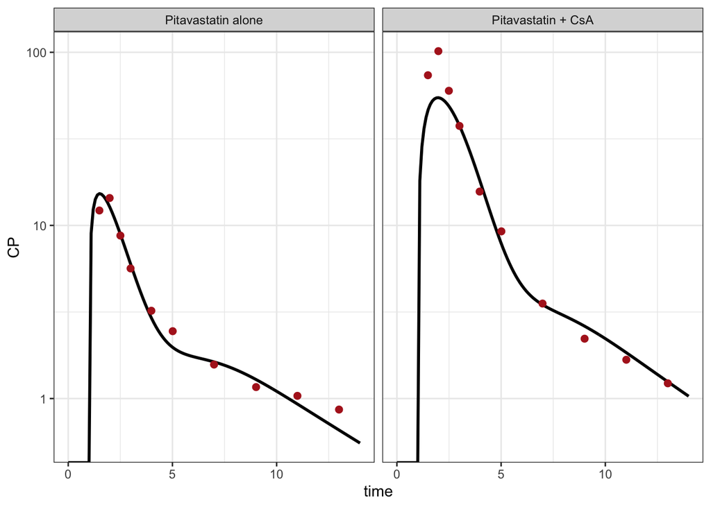

```r
ggplot(df_pred, aes(time,CP)) +
  geom_line(lwd=1) +
  geom_point(data = df_obs, aes(time,DV),col="firebrick",size=2) +
  facet_wrap(~type) + scale_y_log10()
```

### 7.1.3 A nicer plot

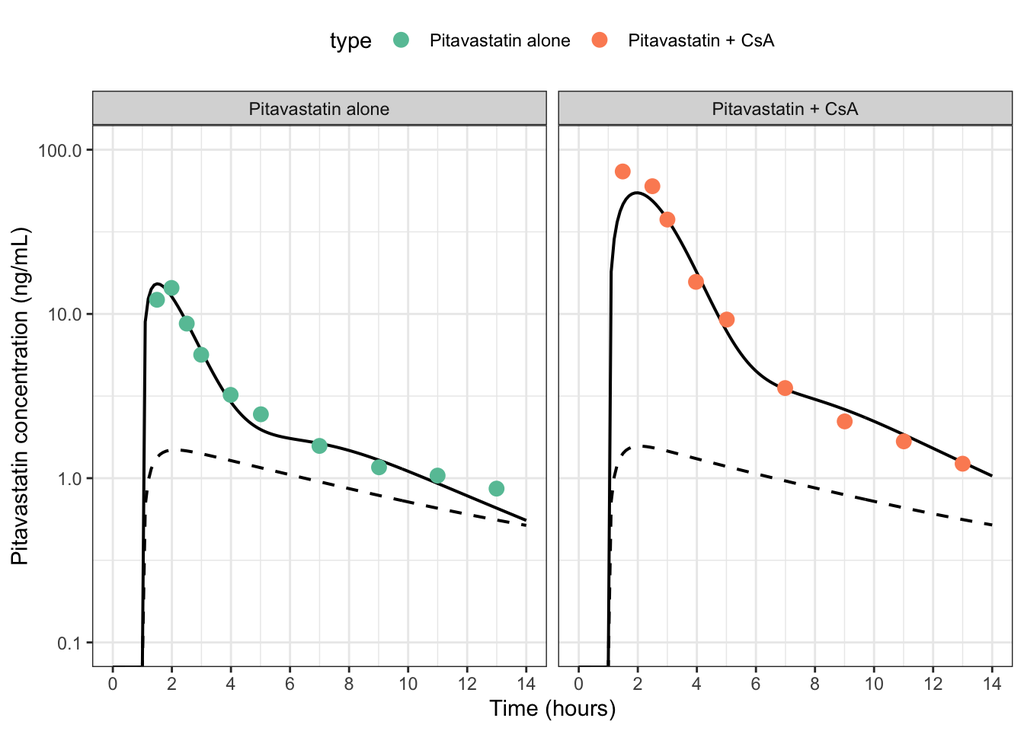

```r
ggplot(data=df_pred) +
  geom_line(data=df_init,aes(time,CP,lty="A"), col="black", lwd=0.7) +
  geom_line(aes(time,CP,lty="B"),col="black",lwd=0.7) +
  geom_point(data=df_obs,aes(time,DV,col=type),size=3) +
  facet_wrap(~type) +
  scale_y_continuous(trans="log",breaks=10^seq(-4,4),
                     limits=c(0.1,100),
                     "Pitavastatin concentration (ng/mL)") +
  scale_x_continuous(name="Time (hours)", breaks=seq(0,14,2)) +
  scale_linetype_manual(values= c(2,1), guide = FALSE,
                        labels=c("Initial estimates", "Final estimates"), name="") +
  theme_bw() + theme(legend.position="top")
```

### 7.1.4 The final objective function value and estimates

```r
sim_ofv(fit$par,data=data)
```

```
. [1] 0.6860763
```

```r
exp(fit$par)
```

```
. [1] 0.81528881 0.01095104 0.34386902 0.98896812 0.68981170
```